Ficha del establecimiento

# Escuela Territorio Antártico

RBD **9415**San MiguelEscuela o liceo

628estudiantes matriculadosCorte Agosto 2026

Mujeres47,0%295 est.

Hombres53,0%333 est.

Chilenos/as56,2%353 est.

Extranjeros/as43,8%275 est.

Actualizada al 05-10-2026

💻Ver ficha completaVersión para computador, con mapas y gráficos interactivos. Pesa varios MB: mejor ábrela con wifi.

🏛️Identificación

## Identificación del establecimiento

Los datos de contacto y las características básicas del establecimiento, tal como están registrados en el Ministerio de Educación. **Si algo está mal o falta, escríbenos** y lo corregimos en la próxima actualización.

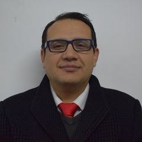

Director o directora

Tomás Enrique Huerta Calderon

**Nombre**

Escuela Territorio Antártico

**RBD**

9415

**Dirección**

Tercera Transversal 5950

**Comuna**

San Miguel

**Tipo**

Escuela o liceo

**Estado**

✅En funcionamiento

**Director/a**

Tomás Enrique Huerta Calderon

**Correo**

escuelaterritorioantartico@slepsantarosa.cl

**Teléfono**

3144688

**Sitio web**

—

**Matrícula**

GRATUITO

**Sostenedor**

El sostenedor corresponde a una persona jurídica

**Orientación**

Orientación religiosa Laica

### Niveles que imparte

✓ 🧸 Educación Parvularia✓ 🎒 Enseñanza Básica Niños

### Vulnerabilidad del alumnado

Índice de vulnerabilidad (IVE)

81,5%

Lo calcula JUNAEB y sirve para asignar programas de apoyo.

0%100%

Este establecimientoPromedio de la comuna 62%

Prioritarios en Básica

69,7%

Estudiantes en 1ª, 2ª o 3ª prioridad.

**Un IVE más alto significa más necesidad de apoyo**, no peor calidad. Se usa para decidir a qué establecimientos llegan primero los programas de alimentación, salud y becas.

### Apoyos profesionales al aprendizaje

✓ 📚 Reforzamiento✓ 🧠 Psicólogo/a✓ 🧭 Orientador/a✓ 👩‍🏫 Profesor/a de educación especial✓ 🤝 Asistente social✓ 🗣️ Fonoaudiólogo/a✓ ➕ Otro: COORDINACIONES DE FORMACIÓN, DEPORTE Y GÉNERO🧩 Psicopedagogo/a🎓 Orientación vocacional

### Infraestructura y atención a la diversidad

✓ 📚 Biblioteca✓ 🌐 Computadores con internet✓ 🖥️ Sala de informática✓ 📽️ Sala audiovisual✓ 🏟️ Cancha deportiva✓ ♿ Accesibilidad NEE✓ ➕ Otra: SALA CON PIZARRA INTERACTIVA (1)🔬 Laboratorio🏛️ Sala multiuso💻 Computadores🤾 Gimnasio

✓ 🦽 Discapacidad motora✓ 🧩 Trastorno del espectro autista✓ 📖 Dificultades de aprendizaje✓ 🗣️ Trastorno específico del lenguaje✓ 🎯 Déficit atencional✓ 📊 Funcionamiento intelectual limítrofe👁️ Discapacidad visual👂 Discapacidad auditiva🧠 Discapacidad intelectual💬 Trastornos de la comunicación

Las etiquetas con ✓ son las que el establecimiento declaró en el directorio oficial; las grises no están marcadas.

### Jornada Escolar Completa (JEC)

Cursos con jornada completa

Cursos sin jornada completa

**Ver curso por curso**

| Grado | Cursos | Jornada |
| --- | --- | --- |
| 1° Básico | 2 | — Sin JEC |
| 2° Básico | 2 | — Sin JEC |
| 3° Básico | 2 | ✅ Con JEC |
| 4° Básico | 2 | ✅ Con JEC |
| 5° Básico | 2 | ✅ Con JEC |
| 6° Básico | 1 | ✅ Con JEC |
| 7° Básico | 2 | ✅ Con JEC |
| 8° Básico | 2 | ✅ Con JEC |
| Kínder | 1 | — Sin JEC |
| Pre-kínder | 1 | — Sin JEC |

Con **Jornada Escolar Completa** los estudiantes tienen más horas de clases al día y almuerzan en el establecimiento.

### Idiomas

**Inglés en Enseñanza Básica**

Básico

### Certificación ambiental (SNCAE)

El establecimiento no tiene certificación del Sistema Nacional de Certificación Ambiental de Establecimientos Educacionales (SNCAE).

### Concentración de alumnado prioritario

Concentración 2026

37,3%

▼5,24 pts

Porcentaje de estudiantes prioritarios reconocidos por el Mineduc.

0%100%

Concentración del establecimiento

Concentración 2025

42,5%

Resolución exenta

2026

Observación del Ministerio: **Sin ACAP 2025-2026**.

La **concentración de prioritarios** define cuánta Subvención Escolar Preferencial (SEP) recibe el establecimiento. Sobre 60 % da acceso a la asignación por concentración.

### Requisitos para postular

✓ 🎂 Cumplir la edad mínima✓ 📄 Certificado de nacimiento✓ 📊 Certificado de notas✓ 🏠 Ficha de protección social✓ ✍️ Firmar el proyecto educativo✓ ⚖️ Firmar el reglamento de convivencia📝 Informe de personalidad🧪 Test de intereses♿ Informe de necesidades educativas📋 Examen de ingreso👥 Entrevista con apoderados🎲 Sorteo💍 Certificado de matrimonio⛪ Certificado de bautismo⛪ Certificado de matrimonio religioso💰 Pago de postulación➕ Otro

Desde el Sistema de Admisión Escolar, los establecimientos públicos **no pueden seleccionar** por rendimiento ni por antecedentes socioeconómicos. Estos son los antecedentes administrativos que el establecimiento declara pedir.

**Equipo del SLEP que acompaña al establecimiento**

**Asesor/a territorial**

PILAR SOBARZO CANDIA

**Correo UTP**

utp.escuelaterritorioantartico@slepsantarosa.cl

**Correo Inspectoría**

inspectoria.escuelaterritorioantartico@slepsantarosa.cl

🏫Matrícula

## Matrícula y asistencia

Cuántos estudiantes tiene el establecimiento, quiénes son y cuántos días van efectivamente a clases. **La asistencia es el porcentaje de días que los estudiantes asistieron** sobre los días en que estuvieron matriculados.

Matrícula · Agosto 2026

628

▲0,8%

Variación desde el primer mes del año escolar.

1141.024

Este establecimientoPromedio del SLEP 333

Asistencia promedio

88,5%

Días asistidos sobre días matriculados.

22,7%93,4%

Este añoPromedio de años anteriores 71,2%

Cursos

17

Niveles

2

Matrícula regular

628

Estudiantes en la modalidad regular del establecimiento.

Matrícula no regular

0

Modalidades de adultos, reingreso o validación de estudios.

Matrícula mes a mes · 2026

Cuántos estudiantes había registrados al cierre de cada mes.

Asistencia mes a mes · 2026

Porcentaje de días asistidos sobre los días en que el estudiante estuvo matriculado.

Matrícula año a año

Matrícula del último mes de cada año escolar.

### Quiénes estudian acá

Por género

Hombres · 333Mujeres · 295

Por origen

Chilenos/as · 353Extranjeros/as · 275Nacionalizados/as · 0

Nacionalidades presentes

Número de estudiantes por país de nacimiento declarado.

🇨🇱 Chilena437

🇻🇪 Venezolana101

🌐 Otra47

🇨🇴 Colombiana18

❔ Sin información8

🇧🇴 Boliviana5

Otros8

Pueblos originarios

Estudiantes que declaran pertenecer a un pueblo originario.

🌿 Mapuche5

### Por nivel de enseñanza

Matrícula por nivel

🧸 Educación Parvularia67

🎒 Enseñanza Básica Niños561

Asistencia por nivel

La escala va de 0 % a 100 %.

🧸 Educación Parvularia80,6%

🎒 Enseñanza Básica Niños89,4%

### Asistencia por grupo

Asistencia por género

Promedio ponderado por el número de estudiantes de cada grupo.

Hombres88,4%

Mujeres88,6%

Asistencia por origen

Chilenos/as85,7%

Extranjeros/as92,1%

Asistencia por nacionalidad

Solo los seis grupos con más estudiantes.

🇨🇱 Chilena87,6%

🇻🇪 Venezolana93,0%

🌐 Otra89,0%

🇨🇴 Colombiana89,6%

❔ Sin información86,4%

🇧🇴 Boliviana0,0%

Asistencia por pueblo originario

🌿 Mapuche97,1%

**Ver el detalle curso por curso (17 cursos)**

| Curso | Matrícula | Asistencia % |
| --- | --- | --- |
| Pre-kínder A | 32 | 78,2 |
| Kínder A | 35 | 82,9 |
| 1° Básico A | 29 | 88 |
| 1° Básico B | 29 | 87,2 |
| 2° Básico A | 38 | 87,3 |
| 2° Básico B | 38 | 85,9 |
| 3° Básico A | 38 | 91,2 |
| 3° Básico B | 40 | 91 |
| 4° Básico A | 39 | 90,2 |
| 4° Básico B | 36 | 90,9 |
| 5° Básico A | 38 | 86,6 |
| 5° Básico B | 37 | 91,2 |
| 6° Básico A | 40 | 91 |
| 6° Básico B | 40 | 89 |
| 7° Básico A | 39 | 88,2 |
| 8° Básico A | 40 | 92,1 |
| 8° Básico B | 40 | 90,3 |

**Ver la matrícula año a año, con su variación**

| Periodo | Matrícula | Variación | Cambio |
| --- | --- | --- | --- |
| 2026 | 628 | −25,0 | −3,8% |
| 2025 | 653 | −4,0 | −0,6% |
| 2024 | 657 | +2,0 | +0,3% |
| 2023 | 655 | +2,0 | +0,3% |
| 2022 | 653 | −54,0 | −7,6% |
| 2019 | 707 | +89,0 | +14,4% |
| 2018 | 618 | +63,0 | +11,4% |
| 2017 | 555 | +38,0 | +7,4% |
| 2016 | 517 | — | — |

**Ver la asistencia año a año, con su variación**

| Periodo | Asistencia | Variación | Cambio |
| --- | --- | --- | --- |
| 2026 | 88,5% | +1,4 pts | +1,6% |
| 2025 | 87,1% | +11,4 pts | +15,1% |
| 2024 | 75,7% | −7,8 pts | −9,3% |
| 2023 | 83,5% | −0,2 pts | −0,2% |
| 2022 | 83,7% | +56,1 pts | +203,3% |
| 2019 | 27,6% | −53,6 pts | −66,0% |
| 2018 | 81,2% | +18,9 pts | +30,3% |
| 2017 | 62,3% | −5,9 pts | −8,7% |
| 2016 | 68,2% | — | — |

La matrícula se cuenta al cierre de cada mes, así que los cambios durante el año reflejan traslados y retiros. Corte usado: **Agosto 2026**.

🤝Vida escolar

## Vida escolar y comunidad

Qué actividades ofrece el establecimiento fuera de las clases, cómo se organiza con las familias y quiénes representan a la comunidad. **Las etiquetas con ✓ son las que el establecimiento declaró** en el directorio oficial del Ministerio; las grises no están marcadas.

### Talleres y actividades para estudiantes

✓ 🧭 Orientación✓ 🤝 Convivencia✓ 🚫 Prevención drogas✓ ❤️ Educación sexual✓ 🌱 Medio ambiente✓ 🌟 Vida sana✓ 🫂 Acción social✝️ Pastoral➕ Otra

Actividades de formación: orientación, convivencia, prevención y vida sana.

✓ 🎵 Música✓ ➕ Otro: TALLER FÚTBOL, TALLER DE BASQUETBALL🎭 Teatro📚 Literatura✂️ Manualidades🩰 Danza o ballet🎨 Artes plásticas💻 Taller TIC🎓 Preuniversitario

Talleres de arte, cultura y tecnología fuera del horario de clases.

✓ ⚽ Fútbol✓ 🥅 Baby fútbol✓ 🏐 Vóleibol✓ 🏀 Básquetbol✓ 🏓 Tenis de mesa✓ ♟️ Ajedrez✓ ➕ Otro: HANDBALL🏃 Atletismo🏊 Natación🤸 Gimnasia🎾 Tenis

Disciplinas deportivas que ofrece el establecimiento.

### Trabajo con las familias

✓ 🎉 Actividades de integración✓ 📈 Perfeccionamiento✓ ➕ Otra: ESCUELA PARA PADRES👪 Talleres de formación

✓ 🌐 Web y redes sociales✓ 🗣️ Consejo escolar✓ 📄 Reuniones generales✓ 👥 Entrevistas individuales✓ ➕ Otro: CORREO ELECTRÓNICO📒 Libreta de comunicaciones

Por dónde el establecimiento se comunica con apoderados y apoderadas.

### Organizaciones de la comunidad

**Centro de Padres**

Constituido

**Personalidad jurídica**

Vigente

**Última elección de directiva**

**Centro de Estudiantes**

Constituido

**Representante del sostenedor en el Consejo Escolar**

Eiden Viera Pardo

**Acompañamiento del Consejo Escolar**

Eiden Viera Pardo

Para contactar al centro de padres o al centro de estudiantes, escribe al establecimiento: sus datos están más arriba.

El **Consejo Escolar** es la instancia donde se juntan dirección, docentes, asistentes, apoderados y estudiantes para conversar sobre la marcha del establecimiento.

### Normativa y conectividad

**Uso de uniforme**

Uniforme propio del establecimiento

**Tipo de conexión**

Fibra óptica

**Velocidad de internet**

Alta velocidad

🧭Gestión

## Instrumentos de gestión: PEI y PME

El **PEI** dice quién quiere ser el establecimiento: su misión, su visión y sus sellos. El **PME** dice qué va a hacer este año para lograrlo, con responsables y presupuesto. Son los dos documentos que ordenan el trabajo.

### Proyecto Educativo Institucional (PEI)

**Misión**

“La Escuela Territorio Antártico, es una escuela pública, que contribuye a la formación integral de sus estudiantes, a través de aprendizajes y habilidades que promueven la participación activa, la inclusión y el bien común”.

**Visión**

“Formaremos estudiantes comprometidos con la participación ciudadana, el medio ambiente y la vida saludable, potenciando habilidades que contribuyan al desarrollo sustentable de su entorno”.

### Énfasis declarados, en orden de prioridad

**1º**

Excelencia académica

**2º**

Desarrollo integral

**3º**

Deportivo

### Documentos oficiales

[📘Proyecto Educativo](https://wwwfs.mineduc.cl/Archivos/infoescuelas/documentos/9415/ProyectoEducativo9415.pdf)[⚖️Reglamento de Convivencia](https://wwwfs.mineduc.cl/Archivos/infoescuelas/documentos/9415/ReglamentodeConvivencia9415.pdf)[📊Reglamento de Evaluación](https://wwwfs.mineduc.cl/Archivos/infoescuelas/documentos/9415/ReglamentoDeEvaluacion9415.pdf)

### Plan de Mejoramiento Educativo (PME)

Acciones comprometidas

22

Inversión total del plan

$ 253.892.106

Dimensiones cubiertas

4

Acciones por dimensión

Las cuatro dimensiones del PME: gestión pedagógica, liderazgo, convivencia y recursos.

Gestión Pedagógica9

Convivencia Escolar5

Gestión de Recursos4

Liderazgo4

Quién lidera las acciones

Los cinco responsables con más acciones a cargo.

Director11

Jefe técnico7

Encargado de convivencia2

Equipo de gestión1

Sostenedor1

De dónde sale el financiamiento

Monto comprometido por fuente de recursos.

sep$ 253.892.106

**Ver las 22 acciones del plan**

| Acción | Dimensión | Responsable | Monto |
| --- | --- | --- | --- |
| Acción 1. Servicio de Plataforma Educativa | Gestión Pedagógica | Jefe técnico | $ 4.231.656 |
| Acción 2. Plan de Acompañamiento (Decreto 67) | Gestión Pedagógica | Jefe técnico | $ 0 |
| Acción 3. Asesoría técnica y activ de form, información y orientación para las comunidades educativa | Gestión Pedagógica | Director | $ 0 |
| Acción 4. Extensión horaria para Niveles Sin JEC | Gestión Pedagógica | Jefe técnico | $ 0 |
| Acción 5. Plan de transición educativa (DECRETO 373) | Gestión Pedagógica | Jefe técnico | $ 0 |
| Acción 7. Talleres para la formación integral | Gestión Pedagógica | Jefe técnico | $ 0 |
| Acción 7. Fortalecimiento de la metodología activo participativa ABP. | Gestión Pedagógica | Jefe técnico | $ 4.595.438 |
| Acción 8. Acompañamiento y retroalimentación a los docentes. | Gestión Pedagógica | Jefe técnico | $ 12.919.219 |
| Acción 9. Optimización del tiempo no lectivos. | Gestión Pedagógica | Equipo de gestión | $ 1.919.630 |
| Acción 10. Contratación de profesionales para fortalecer el soporte a los procesos educativos. | Liderazgo | Sostenedor | $ 18.833.538 |
| Acción 11. Fortalecer la presencialidad mediante fidelización, reconocimiento e incent para estud. | Liderazgo | Encargado de convivencia | $ 0 |
| Acción 12. Fortalecer el sentido de pertenencia, compromiso e identidad. | Liderazgo | Encargado de convivencia | $ 554.094 |
| Acción 13. Plan de reconocimiento y participación activa con el medio. | Liderazgo | Director | $ 0 |
| Acción 14. Asistencia y resguardo de las trayectorias educativas (Dupla Psicosocial) | Convivencia Escolar | Director | $ 0 |
| Acción 15. Servicio de transporte escolar para salidas pedagógicas y/o actividades extraescolares. | Convivencia Escolar | Director | $ 3.500.000 |
| Profesional de apoyo en primeros auxilios y de atención a las necesidades educativas | Convivencia Escolar | Director | $ 0 |
| Acción 17. Generación de condiciones para la promoción del cuidado y autocuidado | Convivencia Escolar | Director | $ 4.475.179 |
| Acción 18. Sentido de pertenencia y eventos educativos/culturales | Convivencia Escolar | Director | $ 0 |
| Acción 19. Servicio de equipos multicopiadores para el Apoyo Pedagógico | Gestión de Recursos | Director | $ 2.417.989 |
| Acción 20. Adquisición de Material Escolar para el Apoyo al Aprendizaje | Gestión de Recursos | Director | $ 2.693.209 |
| Acción 21. Contratación de Docentes y/o Asistentes de la Educación para Apoyo Pedagógico | Gestión de Recursos | Director | $ 197.752.154 |
| Acción 22. Fortalecimiento del sistema institucional de seguridad y bienestar escolar | Gestión de Recursos | Director | $ 0 |

**Ver plazos y estado de ejecución de cada acción**

| Acción | Inicio | Término | Nivel de ejecución |
| --- | --- | --- | --- |
| Acción 1. Servicio de Plataforma Educativa | 01/3/2025 | 31/12/2025 | Implementado de manera adecuada (50% a 74%) |
| Acción 2. Plan de Acompañamiento (Decreto 67) | 01/3/2025 | 31/12/2025 | Implementación avanzada (75% a 99%) |
| Acción 3. Asesoría técnica y activ de form, información y orientación para las comunidades educativa | 01/3/2025 | 31/12/2025 | Implementado de manera adecuada (50% a 74%) |
| Acción 4. Extensión horaria para Niveles Sin JEC | 01/3/2025 | 31/12/2025 | Implementación avanzada (75% a 99%) |
| Acción 5. Plan de transición educativa (DECRETO 373) | 01/3/2025 | 31/12/2025 | Implementación avanzada (75% a 99%) |
| Acción 7. Talleres para la formación integral | 01/3/2025 | 31/12/2025 | Implementación avanzada (75% a 99%) |
| Acción 7. Fortalecimiento de la metodología activo participativa ABP. | 01/3/2025 | 31/12/2025 | Implementación avanzada (75% a 99%) |
| Acción 8. Acompañamiento y retroalimentación a los docentes. | 01/3/2025 | 31/12/2025 | Implementación avanzada (75% a 99%) |
| Acción 9. Optimización del tiempo no lectivos. | 01/3/2025 | 31/12/2025 | Implementación avanzada (75% a 99%) |
| Acción 10. Contratación de profesionales para fortalecer el soporte a los procesos educativos. | 01/3/2025 | 31/12/2025 | Implementación avanzada (75% a 99%) |
| Acción 11. Fortalecer la presencialidad mediante fidelización, reconocimiento e incent para estud. | 01/3/2025 | 31/12/2025 | Implementación avanzada (75% a 99%) |
| Acción 12. Fortalecer el sentido de pertenencia, compromiso e identidad. | 01/3/2025 | 31/12/2025 | Implementación avanzada (75% a 99%) |
| Acción 13. Plan de reconocimiento y participación activa con el medio. | 01/3/2025 | 31/12/2025 | Implementación avanzada (75% a 99%) |
| Acción 14. Asistencia y resguardo de las trayectorias educativas (Dupla Psicosocial) | 01/3/2025 | 31/12/2025 | Implementación avanzada (75% a 99%) |
| Acción 15. Servicio de transporte escolar para salidas pedagógicas y/o actividades extraescolares. | 01/3/2025 | 31/12/2025 | Implementación avanzada (75% a 99%) |
| Profesional de apoyo en primeros auxilios y de atención a las necesidades educativas | 01/3/2025 | 31/12/2025 | No Implementado (0%) |
| Acción 17. Generación de condiciones para la promoción del cuidado y autocuidado | 01/3/2025 | 31/12/2025 | Implementación avanzada (75% a 99%) |
| Acción 18. Sentido de pertenencia y eventos educativos/culturales | 01/3/2025 | 31/12/2025 | Implementación avanzada (75% a 99%) |
| Acción 19. Servicio de equipos multicopiadores para el Apoyo Pedagógico | 01/3/2025 | 31/12/2025 | Implementación avanzada (75% a 99%) |
| Acción 20. Adquisición de Material Escolar para el Apoyo al Aprendizaje | 01/3/2025 | 31/12/2025 | Implementación avanzada (75% a 99%) |
| Acción 21. Contratación de Docentes y/o Asistentes de la Educación para Apoyo Pedagógico | 01/3/2025 | 31/12/2025 | Implementación avanzada (75% a 99%) |
| Acción 22. Fortalecimiento del sistema institucional de seguridad y bienestar escolar | 01/3/2025 | 31/12/2025 | Implementado (100%) |

**Ver estrategia, programa y medios de verificación**

| Acción | Estrategia | Programa asociado | Medios de verificación |
| --- | --- | --- | --- |
| Acción 1. Servicio de Plataforma Educativa | Perfeccionamiento de la práctica pedagógica para el fortalecimiento de la evaluación formativa y el aprendizaje significativo. | SEP | -Reportes -Informe de notas -Informe Uso de la plataforma |
| Acción 2. Plan de Acompañamiento (Decreto 67) | Perfeccionamiento de la práctica pedagógica para el fortalecimiento de la evaluación formativa y el aprendizaje significativo. | SEP | -Plan de acompañamiento |
| Acción 3. Asesoría técnica y activ de form, información y orientación para las comunidades educativa | Perfeccionamiento de la práctica pedagógica para el fortalecimiento de la evaluación formativa y el aprendizaje significativo. | SEP | -PPT y documentos de la capacitación. -Plan de Desarrollo Profesional Docente. |
| Acción 4. Extensión horaria para Niveles Sin JEC | Perfeccionamiento de la práctica pedagógica para el fortalecimiento de la evaluación formativa y el aprendizaje significativo. | SEP | -Registro de asistencia -Plan de trabajo |
| Acción 5. Plan de transición educativa (DECRETO 373) | Perfeccionamiento de la práctica pedagógica para el fortalecimiento de la evaluación formativa y el aprendizaje significativo. | SEP | -Plan de transición |
| Acción 7. Talleres para la formación integral | Perfeccionamiento de la práctica pedagógica para el fortalecimiento de la evaluación formativa y el aprendizaje significativo. | SEP | -Informe Ejecutivo -Encuesta de Cierre Semestral y anual -Bitácora -Planificación |
| Acción 7. Fortalecimiento de la metodología activo participativa ABP. | Acompañamiento docente a través de visitas al aula y otras instancias, para promover el trabajo colaborativo, para asegurar la organización e implementación curricular. | SEP | -Informe ejecutivo -Planificación de proyectos |
| Acción 8. Acompañamiento y retroalimentación a los docentes. | Acompañamiento docente a través de visitas al aula y otras instancias, para promover el trabajo colaborativo, para asegurar la organización e implementación curricular. | SEP | -Informe ejecutivo de la acción -Bitácora de retroalimentación a docentes |
| Acción 9. Optimización del tiempo no lectivos. | Acompañamiento docente a través de visitas al aula y otras instancias, para promover el trabajo colaborativo, para asegurar la organización e implementación curricular. | SEP | -Informe de impacto y evaluación -Informes de avance -Actas de reuniones |
| Acción 10. Contratación de profesionales para fortalecer el soporte a los procesos educativos. | Desarrollo de actividades de carácter integral que estimulen su labor formativa. | SEP | -Informes de avance y ejecución -Convenios de prestación de servicios |
| Acción 11. Fortalecer la presencialidad mediante fidelización, reconocimiento e incent para estud. | Desarrollo de actividades de carácter integral que estimulen su labor formativa. | SEP | -Informe ejecutivo |
| Acción 12. Fortalecer el sentido de pertenencia, compromiso e identidad. | Implementación actividades articuladas con las distintas coordinaciones en donde se promuevan los sellos, valores y principios del Proyecto Educativo Institucional | SEP | -Informe ejecutivo -Encuesta de percepción -Planificación de actividades |
| Acción 13. Plan de reconocimiento y participación activa con el medio. | Implementación actividades articuladas con las distintas coordinaciones en donde se promuevan los sellos, valores y principios del Proyecto Educativo Institucional | SEP | -Informe ejecutivo de la acción -Encuesta de percepción |
| Acción 14. Asistencia y resguardo de las trayectorias educativas (Dupla Psicosocial) | Implementación de un plan de convivencia escolar creado de manera participativa, como una red de acción entre todos los estamentos de la comunidad educativa. | SEP | -Informe de impacto. -Bitácoras y/o actas de trabajo. -Plan de trabajo |
| Acción 15. Servicio de transporte escolar para salidas pedagógicas y/o actividades extraescolares. | Implementación de un plan de convivencia escolar creado de manera participativa, como una red de acción entre todos los estamentos de la comunidad educativa. | SEP | -Formulario C -Protocolo de seguridad -Programa de Salidas |
| Profesional de apoyo en primeros auxilios y de atención a las necesidades educativas | Desarrollo de acciones identitarias articuladas entre las distintas coordinaciones con foco en el bienestar físico y socioemocional de todos los integrantes de la comunidad educativa. | SEP | -Bitacora Tens -Plan de acción y trabajo en primeros auxilios -Contratación TENS |
| Acción 17. Generación de condiciones para la promoción del cuidado y autocuidado | Desarrollo de acciones identitarias articuladas entre las distintas coordinaciones con foco en el bienestar físico y socioemocional de todos los integrantes de la comunidad educativa. | SEP | -Informe ejecutivo de la acción -Planificación de actividades -Encuesta de percepción |
| Acción 18. Sentido de pertenencia y eventos educativos/culturales | Desarrollo de acciones identitarias articuladas entre las distintas coordinaciones con foco en el bienestar físico y socioemocional de todos los integrantes de la comunidad educativa. | SEP | -Encuesta de satisfacción -Protocolo de seguridad |
| Acción 19. Servicio de equipos multicopiadores para el Apoyo Pedagógico | Utilización de los recursos financieros y humanos de manera eficiente y efectiva, con foco en lo pedagógico. | SEP | -Regimen de material impreso -Contrato de suministro -Informe de impresiones mensuales |
| Acción 20. Adquisición de Material Escolar para el Apoyo al Aprendizaje | Utilización de los recursos financieros y humanos de manera eficiente y efectiva, con foco en lo pedagógico. | SEP | -Informe ejecutivo de impacto de la acción -Facturas -Proceso de compras públicas |
| Acción 21. Contratación de Docentes y/o Asistentes de la Educación para Apoyo Pedagógico | Implementación de cursos y capacitaciones que se requieran de acuerdo a las necesidades del contexto. | SEP | -Informe ejecutivo de acción -Registro de asistencia -Plan de trabajo |
| Acción 22. Fortalecimiento del sistema institucional de seguridad y bienestar escolar | Implementación de cursos y capacitaciones que se requieran de acuerdo a las necesidades del contexto. | SEP | -Informe ejecutivo de la acción -Registro de asistencia -Plan de trabajo |

**Ver la descripción completa y la justificación de cada acción**

| Acción | Qué se hace | Por qué |
| --- | --- | --- |
| Acción 1. Servicio de Plataforma Educativa | La plataforma educativa es una herramienta digital que facilita la planificación, implementación y seguimiento con un enfoque pedagógico. Su propósito es fortalecer la gestión curricular y didáctica, … | El nivel de implementación está dentro del curso adecuado en relación a las fechas programadas. |
| Acción 2. Plan de Acompañamiento (Decreto 67) | Ejecución de Plan de Acompañamiento y contratación o designación de profesional con el objetivo de apoyar a estudiantes que presentan mayores brechas de aprendizaje con el propósito de generar un impa… | El nivel de implementación está dentro del curso adecuado en relación a las fechas programadas. |
| Acción 3. Asesoría técnica y activ de form, información y orientación para las comunidades educativa | Capacitaciones para docentes y asistentes de la educación con temáticas relacionadas en: Desarrollo profesional docente Herramientas digitales para la educación Temáticas en convivencia escolar | El nivel de implementación está dentro del curso adecuado en relación a las fechas programadas. |
| Acción 4. Extensión horaria para Niveles Sin JEC | La extensión horaria de profesionales y técnicos permite a los estudiantes acceder a herramientas de aprendizaje y experiencias educativas alternativas y lúdicas en espacios protegidos, favoreciendo l… | El nivel de implementación está dentro del curso adecuado en relación a las fechas programadas. |
| Acción 5. Plan de transición educativa (DECRETO 373) | Plan de acción que tiene como propósito fundamental promover y resguardar el traspaso entre el nivel NT2 y 1º Básico. | El nivel de implementación está dentro del curso adecuado en relación a las fechas programadas. |
| Acción 7. Talleres para la formación integral | Se realiza contratación de los talleristas en las áreas de deporte y arte, para ambos ciclos, con el propósito de contribuir a la formación integral de nuestros estudiantes. | El nivel de implementación está dentro del curso adecuado en relación a las fechas programadas. |
| Acción 7. Fortalecimiento de la metodología activo participativa ABP. | Apoyar y monitorear el desarrollo de la metodología de Aprendizaje Basado en proyectos como estrategia de aprendizaje colaborativo para potenciar el aprendizaje integral de los y las estudiantes. | El nivel de implementación está dentro del curso adecuado en relación a las fechas programadas. |
| Acción 8. Acompañamiento y retroalimentación a los docentes. | Acompañamiento y retroalimentación del ejercicio profesional docente, con el objetivo de fortalecer las prácticas pedagógicas con foco en los objetivos de clase para el aprendizaje y la mejora continu… | El nivel de implementación está dentro del curso adecuado en relación a las fechas programadas. |
| Acción 9. Optimización del tiempo no lectivos. | Ejecutar instancias de trabajo colaborativo entre docentes a través de comunidades de aprendizaje, utilizando la modalidad de "Club de video" que responda a los requerimientos de convenio ADECO. | El nivel de implementación está dentro del curso adecuado en relación a las fechas programadas. |
| Acción 10. Contratación de profesionales para fortalecer el soporte a los procesos educativos. | Contratación de profesionales especializados para fortalecer la gestión educativa en los establecimientos, optimizando la planificación, seguimiento y evaluación pedagógica. Su labor mejora la enseñan… | El nivel de implementación está dentro del curso adecuado en relación a las fechas programadas. |
| Acción 11. Fortalecer la presencialidad mediante fidelización, reconocimiento e incent para estud. | Se diseñan, desarrollan y articulan una serie de actividades, con el objetivo de mejorar la experiencia de los y las estudiantes, aportando un valor agregado a la escolaridad, entregando refuerzos pos… | El nivel de implementación está dentro del curso adecuado en relación a las fechas programadas. |
| Acción 12. Fortalecer el sentido de pertenencia, compromiso e identidad. | Planificar e implementar variadas actividades pedagógicas, culturales, recreativas e hitos institucionales, para fortalecer el sentido de pertenencia, compromiso e identidad, en relación con el desarr… | El nivel de implementación está dentro del curso adecuado en relación a las fechas programadas. |
| Acción 13. Plan de reconocimiento y participación activa con el medio. | Motivar las acciones personales, grupales e institucionales de todo el personal de nuestra institución por medio de reconocimiento, la participación activa y estímulos que refuercen positivamente su q… | El nivel de implementación está dentro del curso adecuado en relación a las fechas programadas. |
| Acción 14. Asistencia y resguardo de las trayectorias educativas (Dupla Psicosocial) | Contratación de especialistas psicosociales, como trabajadores sociales, psicólogos y coordinadores, para fortalecer el acompañamiento integral de estudiantes y garantizar su continuidad educativa. Se… | El nivel de implementación está dentro del curso adecuado en relación a las fechas programadas. |
| Acción 15. Servicio de transporte escolar para salidas pedagógicas y/o actividades extraescolares. | El servicio de transporte escolar para salidas pedagógicas y extraescolares facilita el acceso de estudiantes a experiencias fuera del aula, enriqueciendo su formación integral. Mediante visitas a esp… | El nivel de implementación está dentro del curso adecuado en relación a las fechas programadas. |
| Profesional de apoyo en primeros auxilios y de atención a las necesidades educativas | La incorporación de un TENS en los establecimientos permite brindar atención oportuna en emergencias escolares, resguardando la seguridad y bienestar de los estudiantes. Además, favorece la continuida… | No se ha realizado la solicitud. |
| Acción 17. Generación de condiciones para la promoción del cuidado y autocuidado | Espacios para el autocuidado y el trabajo colaborativo, promoviendo el compromiso e identidad con la institución. | El nivel de implementación está dentro del curso adecuado en relación a las fechas programadas. |
| Acción 18. Sentido de pertenencia y eventos educativos/culturales | Diseñar iniciativas para fortalecer el sentido de pertenencia de la comunidad educativa, mediante ritos, salidas pedagógicas, actividades deportivas, artísticas y otras acciones promocionales y de apo… | El nivel de implementación está dentro del curso adecuado en relación a las fechas programadas. |
| Acción 19. Servicio de equipos multicopiadores para el Apoyo Pedagógico | ontratación de servicio de multicopiado para imprimir material didáctico de calidad, fortaleciendo la enseñanza y el aprendizaje. Facilita el acceso equitativo a guías, evaluaciones y recursos gráfico… | El nivel de implementación está dentro del curso adecuado en relación a las fechas programadas. |
| Acción 20. Adquisición de Material Escolar para el Apoyo al Aprendizaje | Adquisición de material escolar y pedagógico para garantizar que todos los estudiantes cuenten con los recursos necesarios, promoviendo equidad y participación en el aula. Estos insumos facilitan la p… | El nivel de implementación está dentro del curso adecuado en relación a las fechas programadas. |
| Acción 21. Contratación de Docentes y/o Asistentes de la Educación para Apoyo Pedagógico | "La contratación de docentes y asistentes de la educación busca fortalecer los procesos pedagógicos mediante acompañamiento especializado. Su labor incluye apoyo en el aula, atención a la diversidad y… | El nivel de implementación está dentro del curso adecuado en relación a las fechas programadas. |
| Acción 22. Fortalecimiento del sistema institucional de seguridad y bienestar escolar | Desarrollar e implementar un plan interno de fortalecimiento en materias de seguridad y bienestar escolar, que incluya la actualización de protocolos, difusión a los funcionarios y realización de inst… | El nivel de implementación está dentro del curso adecuado en relación a las fechas programadas. |

🏆SNED

## SNED · Sistema Nacional de Evaluación del Desempeño

El SNED evalúa cada dos años el desempeño de los establecimientos municipales y particulares subvencionados. Mira **seis factores**: efectividad, superación, igualdad de oportunidades, iniciativa, integración y mejoramiento.

⚪No seleccionado

Índice SNED del establecimiento

Va de 0 a 100 y resume los seis factores que evalúa el sistema.

Los seis factores, uno por uno

Cada factor va de 0 a 100. Los de arriba pesan más en el índice final.

Efectividad54,1%

Superación43,2%

Igualdad de oportunidades94,0%

Iniciativa87,3%

Integración68,2%

Mejoramiento100,0%

**¿Cuánto pesa cada factor?**

| Factor | Puntaje | Peso en el índice (%) |
| --- | --- | --- |
| Efectividad | 54,1 | 37 |
| Superación | 43,2 | 28 |
| Igualdad de oportunidades | 94 | 22 |
| Iniciativa | 87,3 | 6 |
| Integración | 68,2 | 5 |
| Mejoramiento | 100 | 2 |

El SNED premia con un bono a los equipos de los establecimientos con mejor desempeño dentro de un grupo de escuelas parecidas. **No es una nota**: compara con establecimientos de condiciones similares, no con todo Chile.

💼Ocupación

## Ocupación de cupos

Cuántos de los cupos que el establecimiento ofreció están efectivamente ocupados. **Se calcula dividiendo la matrícula actual por los cupos declarados** en el Sistema de Admisión Escolar (SAE).

✅Prácticamente lleno

Ocupación de los cupos

La marca gris señala el 100 %: por sobre esa línea hay más estudiantes que cupos declarados.

Cupos declarados (SAE)

670

Matrícula al corte

628

Agosto 2026

Cupos libres

42

Cupos que quedan sin usar.

Vacantes en el curso de ingreso

35

**Ver los cupos declarados por grado**

| Grado | Cursos | Cupos |
| --- | --- | --- |
| 1° Básico | 2 | 80 |
| 2° Básico | 2 | 80 |
| 3° Básico | 2 | 80 |
| 4° Básico | 2 | 80 |
| 5° Básico | 2 | 80 |
| 6° Básico | 1 | 40 |
| 7° Básico | 2 | 80 |
| 8° Básico | 2 | 80 |
| Kínder | 1 | 35 |
| Pre-kínder | 1 | 35 |

La ocupación compara la **matrícula efectiva** con los **cupos que el establecimiento declaró** en el Sistema de Admisión Escolar. Una ocupación baja no siempre es mala: puede ser espacio para crecer.

♿PIE

## Programa de Integración Escolar (PIE)

Cuántos estudiantes reciben apoyos del PIE y qué tipo de apoyo necesitan. Las **necesidades permanentes** acompañan toda la trayectoria escolar; las **transitorias** requieren apoyo por un tiempo determinado.

Estudiantes en PIE · 2026

85

Se cuenta cada estudiante una sola vez.

0,0%40,0%

Porcentaje de la matrícula

NEE permanentes

22

Acompañan toda la trayectoria escolar.

NEE transitorias

63

Requieren apoyo por un tiempo acotado.

Sobre la matrícula

13,5%

Tipo de necesidad educativa

NEE permanentes · 22NEE transitorias · 63

Por género

Hombres · 54Mujeres · 31

Diagnósticos más frecuentes

Los ocho diagnósticos con más estudiantes.

Trastorno del Lenguaje26

Trastorno del Espectro Autista21

Dificultades Específicas del Aprendizaje16

Funcionamiento Intelectual Limítrofe12

Trastorno de Déficit Atencional9

Discapacidad Intelectual1

En qué cursos están

6° Básico13

2° Básico12

8° Básico12

4° Básico11

5° Básico11

3° Básico10

1° Básico6

7° Básico5

Kínder5

Por nivel de enseñanza

Enseñanza Básica Niños80

Educación Parvularia5

**Ver el cruce entre género y tipo de necesidad**

| Genero | PERMANENTE | TRANSITORIO |
| --- | --- | --- |
| Femenino | 6 | 25 |
| Masculino | 16 | 38 |

**Ver el cruce entre género y los diagnósticos más frecuentes**

| Genero | Dificultades Específicas del Aprendizaje | Funcionamiento Intelectual Limítrofe | Trastorno de Déficit Atencional | Trastorno del Espectro Autista | Trastorno del Lenguaje |
| --- | --- | --- | --- | --- | --- |
| Femenino | 8 | 3 | 3 | 5 | 11 |
| Masculino | 8 | 9 | 6 | 16 | 15 |

**Ver todos los diagnósticos registrados**

| Diagnóstico | Tipo de NEE | Estudiantes |
| --- | --- | --- |
| Trastorno del Lenguaje | TRANSITORIO | 26 |
| Trastorno del Espectro Autista | PERMANENTE | 21 |
| Dificultades Específicas del Aprendizaje | TRANSITORIO | 16 |
| Funcionamiento Intelectual Limítrofe | TRANSITORIO | 12 |
| Trastorno de Déficit Atencional | TRANSITORIO | 9 |
| Discapacidad Intelectual | PERMANENTE | 1 |

### Postulaciones al programa, por período

Estudiantes por año y período

El período **Regular** es la postulación anual; **Extraordinario** y **Excepcionalidad** son cupos que se abren después.

2026 · Excepcionalidad4

2026 · Regular110

2025 · Excepcionalidad4

2025 · Regular110

2024 · Regular + Excepcionalidad116

**Ver el detalle por año, período y tipo de necesidad**

| Año | Período | Tipo de NEE | Estudiantes |
| --- | --- | --- | --- |
| 2.026 | Excepcionalidad | PERMANENTE | 4 |
| 2.026 | Regular | PERMANENTE | 28 |
| 2.026 | Regular | TRANSITORIO | 82 |
| 2.025 | Excepcionalidad | PERMANENTE | 4 |
| 2.025 | Regular | PERMANENTE | 29 |
| 2.025 | Regular | TRANSITORIO | 81 |
| 2.024 | Regular + Excepcionalidad | PERMANENTE | 35 |
| 2.024 | Regular + Excepcionalidad | TRANSITORIO | 81 |

Evolución del programa

Fuente: base territorial del Área de Inclusión Educativa del SLEP.

El PIE entrega apoyos dentro del aula a estudiantes con necesidades educativas especiales. **Estar en PIE no es un diagnóstico permanente**: muchas necesidades son transitorias y se superan con apoyo.

🔄Retiros

## Retiros y movilidad estudiantil

Cuántos estudiantes se retiraron del establecimiento, cuándo y hacia dónde. **Lo importante es saber si volvieron a matricularse en otra parte**: quienes no lo hicieron son los casos que hay que buscar.

Retiros en 2026

63

Equivale al 10,0% de la matrícula actual.

Ya están en otro establecimiento

30

Se confirmó matrícula posterior.

Sin matrícula vigente

6

Requieren seguimiento: pueden estar fuera del sistema.

Pendiente en SIGE

27

Todavía sin información de destino.

En qué meses se producen

Tipo de movimiento

Cambio a otro EE fuera del SLEP30

Sin matrícula24

Cambio a otro EE pertenenciente al SLEP5

Colisión dentro del mismo establecimiento4

A qué establecimientos se van

Los seis destinos más frecuentes.

Sin destino informado24

Escuela Territorio Antártico4

Colegio Part. Los Angeles Santiago De San Mig2

Colegio Santo Tomas De Aquino2

Escuela Consolidada Dávila2

Liceo Municipal El Roble2

Desde qué cursos

1° Básico15

4° Básico8

2° Básico7

5° Básico7

6° Básico7

Pre-kínder7

3° Básico3

7° Básico3

8° Básico3

Kínder3

Qué tipo de establecimiento eligieron

Dependencia del establecimiento de destino.

Sin Matrícula24

Particular Subvencionado22

Mismo Slep9

Otro Slep8

A qué comunas se fueron

Sin información24

San Miguel13

La Cisterna5

Pedro Aguirre Cerda5

San Joaquín3

El Bosque2

La Pintana2

Santiago2

**Ver todos los destinos, uno por uno**

| Establecimiento | Comuna | Dependencia | Estudiantes |
| --- | --- | --- | --- |
| Sin destino informado | — | Sin Matrícula | 24 |
| Escuela Territorio Antártico | San Miguel | Mismo Slep | 4 |
| Colegio Part. Los Angeles Santiago De San Mig | San Miguel | Particular Subvencionado | 2 |
| Colegio Santo Tomas De Aquino | El Bosque | Particular Subvencionado | 2 |
| Escuela Consolidada Dávila | Pedro Aguirre Cerda | Mismo Slep | 2 |
| Liceo Municipal El Roble | La Pintana | Otro Slep | 2 |
| Rosa Marckmann De Gonzalez | La Cisterna | Particular Subvencionado | 2 |
| Centro Educacional Horacio Aravena A. | San Joaquín | Otro Slep | 1 |
| Chilean Eagles College - La Cisterna | La Cisterna | Particular Subvencionado | 1 |
| Colegio Becarb Ii | Calera | Particular Subvencionado | 1 |
| Colegio Bicentenario Santo Cura De Ars | San Miguel | Particular Subvencionado | 1 |
| Colegio Especial Hospitalario De Carabineros | Ñuñoa | Particular Subvencionado | 1 |
| Colegio Poliv. Arzobispo Manuel Vicuna | San Joaquín | Particular Subvencionado | 1 |
| Colegio Religioso Santa Margarita | San Miguel | Particular Subvencionado | 1 |
| Colegio Tomas Moro | San Miguel | Particular Subvencionado | 1 |
| Complejo Educ.part.monsenor Luis A.perez | Pedro Aguirre Cerda | Particular Subvencionado | 1 |
| Esc. Esp. Vocare | San Joaquín | Particular Subvencionado | 1 |
| Escuela Bas. Oscar Encalada Yovanovich | La Cisterna | Mismo Slep | 1 |
| Escuela Basica Latinoamericana | Estación Central | Otro Slep | 1 |
| Escuela Cristal Chile | Padre Hurtado | Otro Slep | 1 |
| Escuela De Parvulos Antu-Huilen | Independencia | Otro Slep | 1 |
| Escuela Especial De Lenguaje El Rincon De Los Sueños | San Miguel | Particular Subvencionado | 1 |
| Escuela General Básica Santa Fe | San Miguel | Mismo Slep | 1 |
| Escuela Lo Calvo | San Esteban | Otro Slep | 1 |
| Escuela Pablo De Tarso | La Cisterna | Particular Subvencionado | 1 |
| Escuela Particular Miguel Davila | Pedro Aguirre Cerda | Particular Subvencionado | 1 |
| Escuela Particular Rocio De Los Angeles | Pedro Aguirre Cerda | Particular Subvencionado | 1 |
| Escuela Particular Y Colegio Chile | San Miguel | Particular Subvencionado | 1 |
| Escuela Villa San Miguel | San Miguel | Mismo Slep | 1 |
| Instituto Hermanos Matte | Santiago | Particular Subvencionado | 1 |
| Liceo Bicentenario Nueva Aurora De Chile | Recoleta | Particular Subvencionado | 1 |
| Liceo Politec. Pdte. Gabriel Gonzalez Videla | Santiago | Otro Slep | 1 |

Un retiro no siempre es una pérdida: muchas veces la familia se cambia de comuna. Lo que sí requiere seguimiento son los estudiantes **sin matrícula vigente** en ningún otro establecimiento.

📚Resultados

## Resultados educativos

Cómo les fue a los estudiantes en sus notas y cuántos pasaron de curso. El **promedio general** va de 1,0 a 7,0 y la **tasa de aprobación** es el porcentaje de estudiantes que fue promovido al curso siguiente.

Promedio general · 2025

6,3de 7,0

Promedio de todas las notas finales, ponderado por el tamaño de cada curso.

5,46,3

Este establecimientoPromedio del SLEP 5,9

Tasa de aprobación

99,1%

Promovidos sobre el total de estudiantes con situación final.

50%100%

Este establecimientoPromedio del SLEP 97%

Estudiantes promovidos

580

Estudiantes reprobados

5

Cómo terminó el año 2025

Situación final de cada estudiante al cierre del año escolar.

Promovidos · 580Reprobados · 5Retirados · 13Trasladados · 45

Promedio general año a año

Escala de notas de 1,0 a 7,0.

Tasa de aprobación año a año

Porcentaje de estudiantes promovidos.

**Ver el detalle por curso (8 grados)**

| Grado | Estudiantes | Promedio | Aprobación % |
| --- | --- | --- | --- |
| 1° Básico | 87 | 6,4 | 98,6 |
| 2° Básico | 83 | 6,4 | 98,7 |
| 3° Básico | 85 | 6,4 | 98,8 |
| 4° Básico | 89 | 6,2 | 98,7 |
| 5° Básico | 84 | 6,2 | 100 |
| 6° Básico | 42 | 6,2 | 100 |
| 7° Básico | 89 | 6,2 | 100 |
| 8° Básico | 84 | 6,2 | 98,8 |

### Aprobación por grupo

Tasa de aprobación por género

Masculino98,8%

Femenino99,6%

Tasa de aprobación por origen

Extranjero99,4%

Chileno98,9%

**Ver el promedio de notas por grupo**

| Género | Estudiantes | Promedio | Aprobación % |
| --- | --- | --- | --- |
| Masculino | 362 | 6,2 | 98,8 |
| Femenino | 281 | 6,3 | 99,6 |

| Origen | Estudiantes | Promedio | Aprobación % |
| --- | --- | --- | --- |
| Extranjero | 348 | 6,3 | 99,4 |
| Chileno | 295 | 6,2 | 98,9 |

### Cómo terminó cada año

Año 2025

Promovidos · 580Reprobados · 5Retirados · 13Trasladados · 45

Año 2024

Año 2023

Año 2022

**Ver la tabla de situación final año a año**

| Año | Promovidos | Reprobados | Retirados | Trasladados |
| --- | --- | --- | --- | --- |
| 2.025 | 580 | 5 | 13 | 45 |
| 2.024 | 578 | 9 | 30 | 42 |
| 2.023 | 578 | 10 | 21 | 24 |
| 2.022 | 572 | 12 | 32 | 42 |

**Ver el promedio y la aprobación año a año**

| Periodo | Promedio | Variación | Cambio |
| --- | --- | --- | --- |
| 2025 | 6,3 | +0,1 | +1,0% |
| 2024 | 6,2 | +0,0 | +0,5% |
| 2023 | 6,2 | +0,1 | +2,0% |
| 2022 | 6,1 | — | — |

| Periodo | Aprobación | Variación | Cambio |
| --- | --- | --- | --- |
| 2025 | 99,1% | +0,6 pts | +0,6% |
| 2024 | 98,5% | +0,2 pts | +0,2% |
| 2023 | 98,3% | +0,4 pts | +0,4% |
| 2022 | 97,9% | — | — |

La tasa de aprobación deja fuera a quienes se retiraron o se trasladaron durante el año: **solo considera a quienes terminaron el año en el establecimiento**.

📐SIMCE

## SIMCE

El SIMCE es la prueba que aplica la Agencia de Calidad para saber cuánto aprendieron los estudiantes en Lectura y Matemática. Además del puntaje, muestra **cuántos estudiantes quedaron en cada nivel de aprendizaje**: Insuficiente, Elemental o Adecuado.

### Categoría de desempeño

⚠️Básica 2019: MEDIO-BAJO

La categoría de desempeño la asigna la Agencia de Calidad y considera resultados **y** el contexto social del establecimiento. Va de Alto a Insuficiente.

### Resultados por curso

Última medición disponible: **2025**.

Lectura

268pts

▼6 pts

Variación respecto de la medición anterior.

244296

Última mediciónPromedio de años anteriores 273

Matemática

248pts

▲3 pts

Variación respecto de la medición anterior.

232281

Última mediciónPromedio de años anteriores 247

### ¿El cambio es real?

•Lectura ■Sin cambio significativo•Matemática ■Sin cambio significativo

La Agencia de Calidad indica si la diferencia con la medición anterior es **estadísticamente significativa**. Si no lo es, el cambio puede deberse al azar.

Niveles de aprendizaje · Lectura

Porcentaje de estudiantes en cada nivel de logro.

Insuficiente · 31,8%Elemental · 33,3%Adecuado · 34,8%

Niveles de aprendizaje · Matemática

Porcentaje de estudiantes en cada nivel de logro.

Insuficiente · 55,4%Elemental · 27,7%Adecuado · 16,9%

Evolución de los puntajes

Puntaje promedio del establecimiento en cada medición.

LecturaMatemática

**Comparar con establecimientos de condiciones parecidas**

| Prueba | Este establecimiento | Grupo de comparación | Diferencia |
| --- | --- | --- | --- |
| Lectura | 268 | 284 | −16 pts |
| Matemática | 248 | 270 | −22 pts |

El grupo de comparación reúne establecimientos con estudiantes de condiciones socioeconómicas similares.

**Ver todos los puntajes históricos**

| Prueba | Año | Puntaje | Estudiantes |
| --- | --- | --- | --- |
| Lectura | 2016 | 248 | 62 |
| Lectura | 2017 | 280 | 35 |
| Lectura | 2018 | 279 | 70 |
| Lectura | 2022 | 266 | 70 |
| Lectura | 2023 | 292 | 35 |
| Lectura | 2024 | 274 | 67 |
| Lectura | 2025 | 268 | — |
| Matemática | 2016 | 235 | 57 |
| Matemática | 2017 | 239 | 37 |
| Matemática | 2018 | 240 | 65 |
| Matemática | 2022 | 246 | 63 |
| Matemática | 2023 | 278 | 35 |
| Matemática | 2024 | 245 | 67 |
| Matemática | 2025 | 248 | — |

Los puntajes SIMCE van aproximadamente de 100 a 400. Una diferencia de menos de 10 puntos entre dos años **no suele ser significativa**: conviene mirar la tendencia de varios años, no el salto de uno.

🌱IDPS

## Indicadores de Desarrollo Personal y Social

Los IDPS miden cosas que no salen en una prueba: si los estudiantes se sienten capaces de aprender, si el ambiente es sano, si participan y si tienen hábitos saludables. **Van de 0 a 100** y se comparan con establecimientos de condiciones parecidas.

Última medición disponible: **2025**.

Autoestima académica y motivación escolar

68de 100

▼6 pts

Variación respecto de la medición anterior.

0100

Este establecimientoEstablecimientos parecidos 72

Clima de convivencia escolar

70de 100

▼1 pts

Variación respecto de la medición anterior.

0100

Este establecimientoEstablecimientos parecidos 74

Hábitos de vida saludable

67de 100

▼2 pts

Variación respecto de la medición anterior.

0100

Este establecimientoEstablecimientos parecidos 70

Participación y formación ciudadana

71de 100

▼4 pts

Variación respecto de la medición anterior.

0100

Este establecimientoEstablecimientos parecidos 76

### ¿El cambio es real?

•Autoestima académica y motivación escolar ▼Baja de forma significativa•Clima de convivencia escolar ■Sin cambio significativo•Hábitos de vida saludable ■Sin cambio significativo•Participación y formación ciudadana ■Sin cambio significativo

Evolución de los cuatro indicadores

Autoestima académica y motivación escolarClima de convivencia escolarParticipación y formación ciudadanaHábitos de vida saludable

**Ver todos los puntajes históricos y su grupo de comparación**

| Indicador | Año | Puntaje | Grupo de comparación |
| --- | --- | --- | --- |
| Autoestima académica y motivación escolar | 2025 | 68 | 72 |
| Clima de convivencia escolar | 2025 | 70 | 74 |
| Hábitos de vida saludable | 2025 | 67 | 70 |
| Participación y formación ciudadana | 2025 | 71 | 76 |
| Autoestima académica y motivación escolar | 2024 | 74 | 74 |
| Clima de convivencia escolar | 2024 | 71 | 75 |
| Hábitos de vida saludable | 2024 | 69 | 71 |
| Participación y formación ciudadana | 2024 | 75 | 77 |
| Autoestima académica y motivación escolar | 2023 | 78 | — |
| Clima de convivencia escolar | 2023 | 82 | — |
| Hábitos de vida saludable | 2023 | 76 | — |
| Participación y formación ciudadana | 2023 | 84 | — |
| Autoestima académica y motivación escolar | 2022 | 74 | — |
| Clima de convivencia escolar | 2022 | 76 | — |
| Hábitos de vida saludable | 2022 | 71 | — |
| Participación y formación ciudadana | 2022 | 78 | — |
| Autoestima académica y motivación escolar | 2018 | 68 | — |
| Clima de convivencia escolar | 2018 | 71 | — |
| Hábitos de vida saludable | 2018 | 62 | — |
| Participación y formación ciudadana | 2018 | 72 | — |
| Autoestima académica y motivación escolar | 2017 | 71 | — |
| Clima de convivencia escolar | 2017 | 68 | — |
| Hábitos de vida saludable | 2017 | 60 | — |
| Participación y formación ciudadana | 2017 | 73 | — |
| Autoestima académica y motivación escolar | 2016 | 69 | — |
| Clima de convivencia escolar | 2016 | 67 | — |
| Hábitos de vida saludable | 2016 | 65 | — |
| Participación y formación ciudadana | 2016 | 71 | — |

Los IDPS se construyen con encuestas a estudiantes, docentes y apoderados. Van de 0 a 100 y **pesan un 33 % en la categoría de desempeño** que la Agencia de Calidad asigna al establecimiento.

📄DIA

## DIA de cierre

El Diagnóstico Integral de Aprendizajes (DIA) se aplica al cierre del año para ver qué aprendieron los estudiantes. **No pone notas**: clasifica a cada estudiante en un nivel de logro para orientar el trabajo del año siguiente.

Estudiantes evaluados

531

Aplicación 2025

En nivel 1 (inicial)

105

En nivel 2 (intermedio)

242

En nivel 3 (adecuado)

184

Cursos evaluados

15

Cómo se reparten los niveles de logro

Cuántos estudiantes quedaron en cada nivel.

Nivel 1 · inicial · 105Nivel 2 · intermedio · 242Nivel 3 · adecuado · 184

Logro promedio por eje de la prueba

Porcentaje de respuestas correctas en cada eje evaluado.

Números y operaciones66,0%

Patrones y álgebra69,0%

Geometría69,2%

Datos y probabilidades65,6%

**Ver el detalle por curso (15 cursos)**

| Curso | Estudiantes | Nivel I | Nivel II | Nivel III |
| --- | --- | --- | --- | --- |
| 1° Básico | 35 | 0 | 2 | 33 |
| 1° Básico | 34 | 0 | 7 | 27 |
| 2° Básico | 38 | 2 | 10 | 26 |
| 2° Básico | 38 | 3 | 16 | 19 |
| 3° Básico | 27 | 0 | 3 | 24 |
| 3° Básico | 29 | 3 | 19 | 7 |
| 4° Básico | 36 | 11 | 21 | 4 |
| 4° Básico | 34 | 9 | 20 | 5 |
| 5° Básico | 37 | 19 | 18 | 0 |
| 5° Básico | 40 | 20 | 18 | 2 |
| 6° Básico | 31 | 13 | 15 | 3 |
| 7° Básico | 34 | 7 | 22 | 5 |
| 7° Básico | 39 | 6 | 24 | 9 |
| 8° Básico | 40 | 9 | 23 | 8 |
| 8° Básico | 39 | 3 | 24 | 12 |

El DIA es una evaluación **de diagnóstico, no una calificación**: sirve para que el equipo docente sepa dónde reforzar. Los niveles van de 1 (requiere más apoyo) a 3 (logro adecuado).

📈PAES

## PAES

La PAES es la prueba que se rinde para postular a la educación superior. Aquí verás **cuántos estudiantes la rindieron** y qué puntaje promedio obtuvieron, comparado con el promedio del SLEP y el nacional.

📭**Este establecimiento no tiene resultados PAES.**La PAES la rinden solo los establecimientos con enseñanza media.

🎓Ed. superior

## Tránsito a la educación superior

Qué pasó con los estudiantes después de egresar: cuántos entraron a una universidad, instituto profesional o centro de formación técnica, y qué estudian. **Se mira el año inmediatamente siguiente al egreso**.

📭**Todavía no hay seguimiento de egresados para este establecimiento.**El seguimiento se construye cruzando los egresados con las matrículas de educación superior.

🛠️Técnico profesional

## Técnico profesional: especialidades y titulación

Qué especialidades técnicas ofrece el establecimiento, cómo les va a los estudiantes de cada una y cuántos alcanzan el **título técnico de nivel medio** después de hacer su práctica profesional.

📭**Este establecimiento no imparte educación técnico-profesional.**Solo entrega formación humanístico-científica o de enseñanza básica.

👔Funcionarios

## Funcionarios del establecimiento

Cuántas personas trabajan en el establecimiento y en qué. La **dotación estable** son quienes tienen contrato titular o a contrata; los **reemplazos** cubren licencias y permisos, así que un número alto puede indicar rotación.

Corte: **Mayo de 2026**.

Funcionarios y funcionarias

73

Personas distintas con contrato vigente.

Dotación estable

68

Titulares y a contrata, sin contar reemplazos.

En reemplazo

5

Es el 6,8% de la dotación.

Jornada promedio

36,7hrs

Horas semanales contratadas.

Docentes y asistentes de la educación

DOCENTE43

ASISTENTE DE LA EDUCACION30

Por función

Las ocho funciones con más personas.

DOCENTES34

ADMINISTRATIVOS9

AUXILIARES DE SERVICIO9

PROFESIONALES Y TECNICOS DE APOYO (PIE/SEP/SALUD)6

TECNICOS EN PARVULOS4

EDUCADORA DE PARVULOS3

COORDINADORES Y SOPORTE ADM.2

DIRECTIVOS2

Composición de la dotación

Docentes y asistentes de la educación, estables y en reemplazo.

Docente estable · 39Asistente estable · 29Docente en reemplazo · 4Asistente en reemplazo · 1

Dotación mes a mes · 2026

Número de contratos vigentes en cada mes.

Dotación mes a mes por categoría

Asistente en reemplazoAsistente estableDocente en reemplazoDocente estable

**Ver el detalle por cargo (17 combinaciones)**

| Cargo o función | Tipo de hora | Personas | Jornada (hrs) |
| --- | --- | --- | --- |
| DOCENTES | TITULAR | 19 | 36,9 |
| DOCENTES | CONTRATA | 11 | 24,5 |
| ADMINISTRATIVOS | TITULAR | 9 | 44 |
| AUXILIARES DE SERVICIO | TITULAR | 7 | 44 |
| PROFESIONALES Y TECNICOS DE APOYO (PIE/SEP/SALUD) | TITULAR | 5 | 35 |
| DOCENTES | REEMPLAZO | 4 | 36 |
| TECNICOS EN PARVULOS | TITULAR | 4 | 36 |
| COORDINADORES Y SOPORTE ADM. | TITULAR | 2 | 40,5 |
| DIRECTIVOS | TITULAR | 2 | 44 |
| EDUCADORA DE PARVULOS | TITULAR | 2 | 38,5 |
| OTROS | TITULAR | 2 | 39,5 |
| ASISTENTES DE AULA E INSPECTORIA | TITULAR | 1 | 35 |
| AUXILIARES DE SERVICIO | CONTRATA | 1 | 44 |
| AUXILIARES DE SERVICIO | REEMPLAZO | 1 | 44 |
| DIRECTORES | CONTRATA | 1 | 44 |
| EDUCADORA DE PARVULOS | CONTRATA | 1 | 40 |
| PROFESIONALES Y TECNICOS DE APOYO (PIE/SEP/SALUD) | CONTRATA | 1 | 6 |

👩‍🏫Carrera docente

## Desarrollo profesional docente

En qué tramo de la Carrera Docente están los profesores y profesoras del establecimiento. Los tramos van de **Acceso** (quienes recién empiezan) a **Experto II**, y dependen de la experiencia y de la evaluación docente.

Corte: **Mayo de 2026**.

Docentes

34

En reemplazo

4

Sin encasillar

2

Es el 5,9% del cuerpo docente.

0%100%

Porcentaje sin encasillar

Docentes por tramo de la Carrera Docente

Los tramos van de Acceso (recién iniciados) a Experto II.

Acceso1

Inicial12

Temprano7

Avanzado10

Experto i2

El tramo lo asigna el Sistema de Desarrollo Profesional Docente según la experiencia y los resultados de la evaluación. **Estar sin encasillar no es una falta**: suele pasar con quienes recién ingresan o están en proceso de evaluación.

🏢Convenios

## Convenios y uso de espacios

Qué organizaciones externas usan las instalaciones del establecimiento fuera del horario de clases, para qué y hasta cuándo.

📭**No hay convenios de uso de espacios registrados.**Se registran acá los acuerdos con clubes, juntas de vecinos u otras organizaciones que usan las instalaciones.

📣Denuncias

## Denuncias y reclamos

Los reclamos que las familias y la comunidad presentaron sobre el establecimiento, por dos vías: **directamente al SLEP** o ante la **Superintendencia de Educación**, que es el organismo fiscalizador.

### Denuncias recibidas por el SLEP

No hay denuncias internas registradas para este establecimiento.

### Denuncias ante la Superintendencia de Educación

Denuncias recibidas

6

Cerradas

4

Pendientes

2

Denuncias por año

Ámbito de la denuncia

CONVIVENCIA6

Tema específico

MALTRATO A PÁRVULOS Y/O ESTUDIANTES5

DISCRIMINACIÓN1

Por dónde entró la denuncia

Portal web4

OIRS presencial1

Telefónico1

**Ver los 6 casos uno por uno**

| Fecha | Tema | Afectado | Estado |
| --- | --- | --- | --- |
| 01-12-2025 | MALTRATO A PÁRVULOS Y/O ESTUDIANTES | ESTUDIANTE | Cerrado |
| 28-11-2025 | MALTRATO A PÁRVULOS Y/O ESTUDIANTES | ESTUDIANTE | Cerrado |
| 26-11-2025 | DISCRIMINACIÓN | ESTUDIANTE | Cerrado |
| 10-10-2025 | MALTRATO A PÁRVULOS Y/O ESTUDIANTES | ESTUDIANTE | Cerrado |
| 24-09-2025 | MALTRATO A PÁRVULOS Y/O ESTUDIANTES | ESTUDIANTE | Pendiente |
| 04-08-2025 | MALTRATO A PÁRVULOS Y/O ESTUDIANTES | ESTUDIANTE | Pendiente |

**Ver el detalle del sub-tema de cada denuncia**

| Fecha | Subtema |
| --- | --- |
| 01-12-2025 | MALTRATO ENTRE ESTUDIANTES (EXCLUYE AL NIVEL PARVULARIO) |
| 28-11-2025 | MALTRATO ENTRE ESTUDIANTES (EXCLUYE AL NIVEL PARVULARIO) |
| 26-11-2025 | DISCRIMINACIÓN POR NECESIDADES EDUCATIVAS ESPECIALES PERMANENTES Y/O TRANSITORIAS (TDA, DISCAPACIDAD FÍSICA Y/O INTELECTUAL, U OTRAS) |
| 10-10-2025 | MALTRATO DE ADULTO A PÁRVULO Y/O ESTUDIANTE |
| 24-09-2025 | MALTRATO ENTRE ESTUDIANTES (EXCLUYE AL NIVEL PARVULARIO) |
| 04-08-2025 | MALTRATO DE ADULTO A PÁRVULO Y/O ESTUDIANTE |

### Procesos administrativos

No hay procesos administrativos asociados a este establecimiento.

Una denuncia **no es una sanción**: es un reclamo que se investiga. Muchas se cierran sin encontrar falta. Lo que importa es que exista el canal y que los casos se tramiten.

👮Seguridad

## Robos y delitos

Los robos y daños que ha sufrido el establecimiento, cuándo ocurrieron y cuánto costaron. **Sirve para decidir dónde reforzar la seguridad**: cámaras, cierres perimetrales o rondas.

Incidentes en 2025

1

Especies sustraídas

$ 500.000

Daños a la propiedad

$ 0

Pérdida total

$ 500.000

Con denuncia policial

1

De 1 incidentes.

Unidad policial más frecuente

12° Comisaria de San Miguel

En qué meses ocurrieron

En qué horario

Madrugada1

Tipo de incidente

Robo en lugar no habitado1

**Ver los incidentes uno por uno**

| Fecha | Horario | Especies | Total |
| --- | --- | --- | --- |
| 08-08-2025 | Madrugada | $ 500.000 | $ 500.000 |

| Fecha | Especies |
| --- | --- |
| 08-08-2025 | 1 computador de escritorio |

Los montos son el avalúo declarado por el establecimiento al informar el incidente. Esta información permite al SLEP **priorizar medidas de seguridad** donde más se necesitan.

📍Ubicación

## Ubicación y entorno

Dónde está el establecimiento, desde dónde llegan sus estudiantes y cómo es el barrio que lo rodea. **Toca el botón para abrir la ubicación** en la aplicación de mapas de tu teléfono.

**Dirección**

Tercera Transversal 5950

**Comuna**

San Miguel

**Región**

RM

**Zona**

Urbana

**Latitud**

-33,50730

**Longitud**

-70,66256

[📍Abrir en Google Maps](https://www.google.com/maps/search/?api=1&query=-33.50729713,-70.66255721)

### Dónde viven los estudiantes

Distancia promedio al colegio

2,4km

Distancia en línea recta desde el domicilio.

0,0 km15,0 km

Promedio del establecimiento

Domicilios ubicados

426

Niñas y jóvenes mujeres

2,9km

Niños y jóvenes hombres

2,1km

Estudiantes chilenos/as

2,4km

De qué comuna vienen

Misma comuna · 270Otra comuna del SLEP · 84Fuera del SLEP · 72

A qué distancia viven

Número de estudiantes en cada tramo de distancia.

Hasta 1 km252

1 a 3 km79

3 a 5 km29

Más de 5 km66

Las distancias son **en línea recta**, no el recorrido real. Se excluyen los domicilios a más de 30 km, que suelen ser errores de geocodificación. No se publican direcciones individuales.

### El barrio alrededor del establecimiento

Niños y jóvenes en la comuna

27.886

Personas de 0 a 17 años según el Censo 2024.

De 0 a 5 años

8.769

De 6 a 13 años

13.086

De 14 a 17 años

6.031

Población migrante en la comuna

26,0%

38.899 personas de 149.778 habitantes.

0%50%

Porcentaje de la comuna

Escolaridad promedio

11,1años

Años de estudio de los mayores de 18 años.

Población en edad escolar de la comuna

Censo 2024, 630 manzanas de San Miguel.

0 a 5 años8.769

6 a 13 años13.086

14 a 17 años6.031

Estos son datos del **Censo 2024 de toda la comuna**, no del establecimiento. Sirven para dimensionar cuántos niños y jóvenes viven en el territorio.

Esta es la versión para celular, con lo esencial. La **ficha completa** tiene todas las secciones, los gráficos interactivos y los mapas; se ve mejor en un computador.

Ver ficha completa